# Homework 4

**Due:** Friday, September 25, 11:59pm on Canvas

**Instructions:**

Begin by downloading the HW 4 template from the course website:

https://sta214-f26.github.io/homework/hw_04_template.qmd

Save this template file to your computer, then open it in RStudio. As you complete the assignment, you will write down your answers to all questions in the file, and include all R code in code chunks.

When you have completed the assignment, render your homework to HTML and submit on Canvas. *You must submit the rendered HTML on Canvas to receive full credit!*

**Collaborators and AI statement:** At the top of your assignment, list any collaborators (Dr. Evans does not count – he is a resource, not a collaborator), and provide an AI statement describing your use of AI to complete the questions. If you did not use AI in any way, let me know that too. If you did use AI, provide: the model used, the HW questions on which you used AI, and a summary of the ways in which AI provided assistance. As described in the syllabus, AI use is permitted on homework assignments, but submissions without a complete AI statement may not receive full credit.

**Code guidelines:**

- If a question requires code, and code is not provided, you will not receive full credit
- You will be graded on the quality of your code. In addition to being correct, your code should also be easy to read

## Diagnostics, deviance, and prediction

### Cook’s distance

Below is the output for a logistic regression model, and the Cook’s distance plot for the fitted model.

```
##
## Call:
## glm(formula = y ~ x, family = binomial)
##
## Coefficients:
##             Estimate Std. Error z value Pr(>|z|)
## (Intercept)  -1.4020     0.3251  -4.313 1.61e-05 ***
## x             1.7475     0.3876   4.509 6.52e-06 ***
## ---
## Signif. codes:  0 '***' 0.001 '**' 0.01 '*' 0.05 '.' 0.1 ' ' 1
##
## (Dispersion parameter for binomial family taken to be 1)
##
##     Null deviance: 126.90  on 101  degrees of freedom
## Residual deviance:  89.53  on 100  degrees of freedom
## AIC: 93.53
##
## Number of Fisher Scoring iterations: 5
```

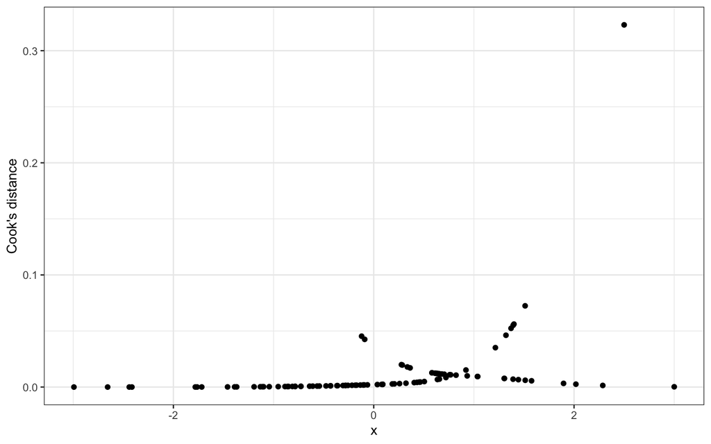

#### Question 1

The largest Cook’s distance is for an observation with $X = 2.5$. However, there is a point with $X = 3$ which has a smaller Cook’s distance. How has this happened? In your answer, use the output provided to discuss what the observed value of $Y$ is for each of these two points.

### Variance inflation factors

Consider a logistic regression model with systematic component

$$\log \left( \dfrac{\pi_i}{1 - \pi_i}
\right) = \beta_0 + \beta_1 X_{i1} + \beta_2 X_{i2} + \cdots + \beta_k
X_{ik}$$

To check for multicollinearity in the explanatory variables (and assess its impact on the estimated coefficients of the model), recall that we can calculate a *variance inflation factor*. The VIF for the $j$th coefficient is defined by

$$VIF_j = \dfrac{Var(\widehat{\beta}_j) \
\text{in the full model (other variables
included)}}{Var(\widehat{\beta}_j) \ \text{when } X_j \text{ is the only
variable in the model}}$$

Suppose we have three explanatory variables, $X_1$, $X_2$, and $X_3$. We fit a logistic regression model with only $X_1$; here are the results:

```r
m1 <- glm(y ~ x1, family = binomial)

summary(m1)
```

```
##
## Call:
## glm(formula = y ~ x1, family = binomial)
##
## Coefficients:
##             Estimate Std. Error z value Pr(>|z|)
## (Intercept) -0.14563    0.09735  -1.496    0.135
## x1           3.28609    0.21212  15.491   <2e-16 ***
## ---
## Signif. codes:  0 '***' 0.001 '**' 0.01 '*' 0.05 '.' 0.1 ' ' 1
##
## (Dispersion parameter for binomial family taken to be 1)
##
##     Null deviance: 1386.29  on 999  degrees of freedom
## Residual deviance:  672.56  on 998  degrees of freedom
## AIC: 676.56
##
## Number of Fisher Scoring iterations: 6
```

From the output, notice that $SE(\widehat{\beta}_1) \approx 0.212$.

We also fit a model with all three variables, and calculate the VIFs:

```r
m2 <- glm(y ~ x1 + x2 + x3, family = binomial)
vif(m2)
```

```
##       x1       x2       x3
## 7.591112 7.067130 7.386217
```

#### Question 2

Using the output provided for the two models, estimate $SE(\widehat{\beta}_1)$ for the *second* model, `m2`.

### Diagnostics

Your friend is interested in doing model diagnostics for a simple logistic regression model. They know that the log-odds are assumed to be a linear function of the explanatory variable. They also know that they can get the *fitted* log-odds for the model in R.

To assess the shape assumption, they therefore decide to write the following code, which produces the plot below:

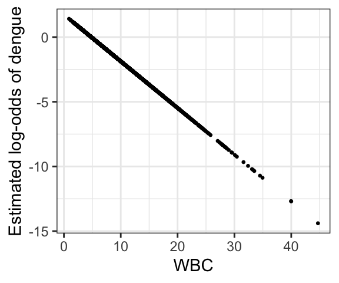

```r
m_dengue <- glm(Dengue ~ WBC, data = dengue, family = binomial)

dengue |>
  mutate(fitted_logit = predict(m_dengue, type = "link")) |>
  ggplot(aes(x = WBC, y = fitted_logit)) +
  geom_point(size=0.5) +
  theme_bw() +
  labs(x = "WBC", y = "Estimated log-odds of dengue")
```

#### Question 3

Examining the plot, they are ecstatic to see a perfectly linear relationship! They conclude that the shape assumption is satisfied.

Comment on your friend’s approach.

### Likelihood

The estimated coefficients for the model fit in question 3 are $\widehat{\beta}_0 = 1.737$ and $\widehat{\beta}_1 = -0.361$.

#### Question 4

Suppose that instead of these estimated coefficients, I decide I prefer $\widehat{\beta}_0 = 1.5$ and $\widehat{\beta}_1 = -0.5$ (on the same data). If I calculate the log-likelihood for the model with these different coefficients (instead of the original coefficients 1.737 and -0.361), how will it change? (Explain whether it will increase, decrease, or stay the same).

### Prediction

Your friend has built a logistic regression model to diagnose a rare disease, using a sample of 10000 patients from providers across NC. To assess their model’s predictive ability, they create a confusion matrix:

|  | Disease negative | Disease positive |
| --- | --- | --- |
| Prediction negative | 9501 | 489 |
| Prediction positive | 6 | 4 |

They calculate the overall accuracy of their predictions, and are ecstatic to obtain an accuracy of 95%!

#### Question 5

Should your friend be happy with their model’s predictive performance? Explain why or why not. Your answer should include a discussion of other metrics for assessing predictive ability (such as sensitivity and specificity).

### More prediction

A different friend of yours is feeling ill, and goes to their doctor. Their doctor diagnoses them with a disease called the *Red Death* (what a horrifying name!). Understandably upset, your friend asks about the reliability of the diagnostic test.

In response, their doctor provides a confusion matrix from a recent study on the Red Death:

|  | Disease negative | Disease positive |
| --- | --- | --- |
| Test negative | 8003 | 10 |
| Test positive | 312 | 95 |

The doctor claims that, *if a patient is positive for the disease*, there is a 90.5% chance that they will test positive. Therefore, the doctor argues that your friend is very likely to truly have the disease.

#### Question 6

Using the confusion matrix, explain how the doctor got the 90.5% probability they reported.

#### Question 7

*Given that your friend tested positive*, how likely is it that they actually have the disease? Calculate a relevant value from the confusion matrix.

Is the doctor correct that your friend is “very likely to truly have the disease”?

# Maximum likelihood estimation

Suppose we have independent samples $(X_1, Y_1), ..., (X_n, Y_n)$ from the linear regression model

$$Y_i = \beta_0 + \beta_1 X_i +
\varepsilon_i \hspace{1cm} \varepsilon_i \sim N(0, 1)$$

This is equivalent to saying that $Y_i \sim N(\beta_0 + \beta_1 X_i, 1)$, which means that

$$P(Y_i| \beta_0, \beta_1) =
\frac{1}{\sqrt{2 \pi}} \exp\left\lbrace-\frac{1}{2} (Y_i - \beta_0 -
\beta_1 X_i)^2 \right\rbrace$$

We now have two parameters to estimate ($\beta_0$ and $\beta_1$), but our likelihood is constructed the same way as before:

$$L(\beta_0, \beta_1) = \prod
\limits_{i=1}^n P(Y_i| \beta_0, \beta_1)$$

#### Question 8

Using this information, show that the log likelihood is

$$\log L(\beta_0, \beta_1) = n \log
\left(\frac{1}{\sqrt{2 \pi}} \right) - \frac{1}{2} \sum \limits_{i=1}^n
(Y_i - \beta_0 - \beta_1 X_i)^2$$

Then, argue that the log likelihood (or equivalently the likelihood) is maximized if we *minimize* the residual sum of squares:

$$SSE = \sum \limits_{i=1}^n (Y_i -
\beta_0 - \beta_1 X_i)^2$$

# Reading a research paper

Statistics is an important research tool used in many fields. In this section of the assignment, you will read the original research article analyzing the dengue data which we have used in class. The purpose of this section is to help you learn how to read a research paper, and extract key details about the study and results. Later, we will try to replicate the authors’ results ourselves.

## Overview

Dengue is a mosquito-borne viral disease which affects hundreds of millions of people each year. Early diagnosis is crucial for patients to have the best prognosis, but relies on a variety of laboratory tests. To enhance practitioners’ ability to diagnose dengue, a 2015 paper by Tuan *et al.* investigated the possibility of detecting dengue using a variety of clinical measurements like white blood cell count and platelet count. This activity will help you read the paper by Tuan *et al.*. The paper is available at

https://journals.plos.org/plosntds/article?id=10.1371/journal.pntd.0003638

## Outline of a research paper

Research papers in many fields, particularly the sciences, often contain the following main sections:

- **Abstract:** A short overview of the full paper, giving highlights of the motivation and background, the research question, the data, and the results.
- **Introduction:** A broad overview of the research question the authors want to study, motivation for studying this question, and the authors’ approach to answering their question. The introduction often starts very general, then narrows to the specific question addressed in this paper. More detail is provided in the introduction than in the abstract, and more time is spent on motivation and related literature.
- **Methods:** The data and analysis techniques used to answer the research question. This typically describes the what the data looks like, how and where it was collected, and any statistical tools (e.g. visualizations, regression, hypothesis testing) that were used when analyzing the data.
- **Results:** A summary of the analysis results, such as figures showing regression fits, and tables of regression coefficients and p-values.
- **Discussion:** A discussion of the analysis results, in context of the original research question. In this section, explanations for *why* particular results were observed may be proposed.
- **Conclusion:** A short summary of the paper and its key results, and their connections to broader scientific questions. The conclusion is often the reverse of the introduction: it starts with the specific question addressed by this paper, then discusses the implications of this research for science in general.

## Reading a research paper

Reading a research paper, particularly in a field in which you are not an expert, can be challenging. The trick is to skim the paper for the most relevant information, and skip over technical details that are not essential to understanding the key take-aways. The questions below will guide you to the most important sections in the paper by Tuan *et al*.

## The Abstract and Introduction

A good place to start is often with the Abstract and Introduction, which allow you get an overview of the paper, and usually don’t contain too many technical details. The Abstract is more succinct than the Introduction, but it also provides less motivation. When the Introduction is long, you may want to skim for key details.

Read the Abstract and introduction. Then answer the following questions.

#### Question 9

Why is it important for the researchers to build a model to detect dengue in hospital patients?

#### Question 10

What is the specific purpose of the research study?

So far, we know what question the researchers are trying to answer, and we know that they are going to build some kind of model to predict dengue. Our goal for the rest of the paper is to understand how the authors conducted this analysis. In particular, we want to answer the following questions:

- Who participated in the study?
- What did the researchers record about each participant?
- What statistical methods did the researchers use?
- What did the researchers conclude from their study?

This information is provided in the Methods and Results sections of the paper. These sections also contain lots of other details which is valuable, but not crucial to understand on a first reading, so we will focus on the most important parts of the Methods and Results.

## Study Participants

Read the *Patient Enrolment* subsection of the Methods, and then answer the following questions.

#### Question 11

How many patients participated in the study?

Potential research subjects must meet certain criteria, defined by the researchers, to participate in a study. *Inclusion* criteria define requirements for inclusion in the study (e.g., a target age range or social group), while *exclusion* criteria are reasons a subject would be asked not to participate (e.g., certain medical conditions).

#### Question 12

What are the inclusion/exclusion criteria for this study?

## Data Collection and Analysis

Now that we know who was studied, we want to know what data was collected about each participant, and how it was analyzed. Read the *Clinical and laboratory investigations on the day of enrollment* and *Statistical methods* subsections of the Methods. Then answer the following questions.

#### Question 13

Which variables were recorded for the patients in the study?

#### Question 14

Which types of statistical methods were used to model the relation between the explanatory variables and whether the patient had dengue? (It is ok if you’re not familiar with all these methods!)

#### Question 15

How did the researchers choose which variables to include in their logistic regression model?

#### Question 16

Which threshold did the researchers use when converting their predicted probabilities into binary predictions?

## Results

Finally, let’s see what the researchers concluded from their statistical models. Read the *Early Dengue Classifier* subsection of the Results, then answer the following questions.

#### Question 17

Which variables did the researchers include in their final logistic regression model?

#### Question 18

What sensitivity and specificity values did the researchers observe using their final model?